# Louvian clusters on hospital network

Susanne Pinto

2025-05

## Load the packages

```r
library( here )
library( tidyverse )
library( haven ) # to import SAS en spss files
library( reshape2 ) # data from long to wide format
library( dplyr ) # remove duplicated rows
library( ggplot2 ) # plots
library( data.table )
library( lubridate ) # merge consecutive rows based on date/time
library( igraph ) # creating network
library( writexl ) # save data as excel
library( anytime ) # work with time in rows
library( mclust )  # MCL clustering
library( viridis ) # color palette
library( cluster ) # obtain optimal k
library( fpc ) # obtain optimal k
library( RColorBrewer ) # palette
library( gplots ) # for heatmap
```

## Load the data

```r
# Read in the opname data
Patient_movements <- read_sas(here( "Patient_movements", "Data", "opnames_pseudo20230725.sas7bdat"))

# Rearrange the columns so pseudo-IDs are the first colums
Patient_movements <- Patient_movements[, c( 1, 14, 13, 2:12 )]

# Sort the data (rows)
Patient_movements1 <- Patient_movements %>%
   arrange( studyId_outbreakdetec_Patient, studyId_outbreakdetec_Hos_ID, hos_start_dt, hos_stop_dt, hos_mut_start_dt, hos_mut_stop_dt )
```

## Use ‘voorkeurs’ PatientID

Some patients have more patientIDs. The way in which hospitalizations in these datasets are linked to patient IDs ensures that a unique hospitalization ID is associated with all patient IDs known for a unique patient, thereby increasing the count for a unique hospitalization by the number of known patient IDs.The file “voorkeurs_id.sas7bdat” contains all studyId_outbreakdetec_Patient entries that are not based on the preferred ID, along with a column named “studyId_outbreakdetec_Pat_voork.” This is the pseudo ID created for the study that takes precedence. Delete the rows that have the same studyId_outbreakdetec_Patient as those in this file.

```r
# Read in the voorkeurs data
preferredID <- read_sas(here("Patient_movements", "Data", "voorkeurs_id.sas7bdat"))

# Sort the data (rows)
preferredID <- preferredID %>%
   arrange( studyId_outbreakdetec_Pat_voork, studyId_outbreakdetec_Patient )

# Filtering rows in Patient_movements1 based on preferredID
# Patient_movements1.filtered will now contain rows from Patient_movements1 where studyId_outbreakdetec_Patient is not in preferredID
Patient_movements1.filtered <- Patient_movements1 %>%
  filter( !studyId_outbreakdetec_Patient %in% preferredID$studyId_outbreakdetec_Patient )

# clean environement
rm( preferredID )
```

## Remove bezwaar patients

This dataset contains the objection of contributing to research etc. First remove the rows for people without objection, then create new variables and give them a value of 1 (bezwaar) or 0 (geen bezwaar). The people have the option of different catagories to which they can object, here if any of the categories was checked we counted it as an objection.

```r
bezwaar <- read_sas(here("Patient_movements", "Data", "bezwaar_umc.sas7bdat"))

# Date of objection
bezwaar <- bezwaar[ !is.na( bezwaar$umc_bezwaar_dt ),]

# Objection to research
bezwaar$research <- ifelse( bezwaar$BezwaarRestOnderZoek == "1", "1", "0" )
bezwaar$research[is.na( bezwaar$research )] <- 0
bezwaar$research1 <- as.numeric( bezwaar$research )

# Objection to education
bezwaar$edu <- ifelse( bezwaar$BezwaarRestOnderWijs == "1", "1", "0" )
bezwaar$edu[is.na( bezwaar$edu )] <- 0
bezwaar$edu1 <- as.numeric( bezwaar$edu )

# Objection to ??
bezwaar$recontact <- ifelse( bezwaar$BezwaarInfoToeval == "1", "1", "0" )
bezwaar$BezwaarInfoToeval[is.na( bezwaar$BezwaarInfoToeval )] <- 0
bezwaar$recontact1 <- as.numeric( bezwaar$recontact )
bezwaar$recontact1[is.na( bezwaar$recontact1 )] <- 0
bezwaar$recontact[is.na( bezwaar$recontact )] <- 0

# Objection to medical data
bezwaar$data <- ifelse( bezwaar$BezwaarMedData == "1", "1", "0" )
bezwaar$data[is.na( bezwaar$data )] <- 0
bezwaar$data1 <- as.numeric( bezwaar$data )

# make a new table and group the variables per patient
bezwaar1 <- bezwaar %>%
  group_by( umc_bezwaar_dt, studyId_outbreakdetec_Patient ) %>%
  summarize( research2 = sum( research1 ),
             edu2 = sum( edu1 ),
             recontact2 = sum( recontact1 ),
             data2 = sum( data1 )) %>%
  arrange( umc_bezwaar_dt, studyId_outbreakdetec_Patient )

# Calculate new datasets based on the values above
bezwaar2 <- bezwaar1 %>% mutate(
  bezwaar3 = research2 + edu2 + data2,
  bezwaar4 = research2 + edu2 + recontact2 + data2,
  recontract3 = if_else( bezwaar4 > bezwaar3 & bezwaar3 > 0, 1, 0 ))
bezwaar2 <- bezwaar2 %>% arrange( studyId_outbreakdetec_Patient, umc_bezwaar_dt )

bezwaar3 <- bezwaar2[ !duplicated( bezwaar2$studyId_outbreakdetec_Patient, fromLast = TRUE ), ]
bezwaar3 <- bezwaar3 %>% arrange( studyId_outbreakdetec_Patient )

# Merge bezwaar3 and Patient_movements1.filtered
Patient_movements1.bezwaar <- merge( bezwaar3, Patient_movements1.filtered, by = c( "studyId_outbreakdetec_Patient" ), all = TRUE)

# Remove patients that were not in the original data, but were in the bezwaar data
Patient_movements1.bezwaar <- Patient_movements1.bezwaar[(Patient_movements1.bezwaar$studyId_outbreakdetec_Patient %in% Patient_movements1$studyId_outbreakdetec_Patient),]
# add is.na to function, because else it does not know what to do with NA values in the bezwaar4 column
Patient_movements1.bezwaar <- Patient_movements1.bezwaar[ !( Patient_movements1.bezwaar$bezwaar4 >= 1 ) | is.na( Patient_movements1.bezwaar$bezwaar4 ), ]

# clean environment
rm( bezwaar, bezwaar1, bezwaar2, bezwaar3 )
```

## Departments

There are many departments, this will make the network unnecessary large and difficult to interpret. Some departments can be removed such as the psychiatric departments, departments of the CHM (military hospital, which should not be included), departments of the emergency hospital, departments with very few admissions (= 1), and a few scattered PMC departments.

```r
# The rows (i.e. departments) I want to exclude, the wards we exclude are:
# Psychiatric departments
# Departments of the CHM (military hospital, also not included in the study)
# Departments of the calamity hospital
# Departments with very few admissions (=1)
# And a few scattered PMC (Pediatric Medical Center) departments
wards_to_exclude <- c( "Behandelcentrum IVF Klinisch", "Calamiteitenhospitaal Crashroom", "Calamiteitenhospitaal IC Ruimte 4",
                      "Calamiteitenhospitaal Low Care 1", "Calamiteitenhospitaal Low Care 2", "Calamiteitenhospitaal Medium Care",
                      "Centrum Dagdiagnostisch kinderneurologie", "Dt Ontwikkeling in Perspectief", "IC Fx / Calamiteiten Ruimte 1",
                      "IC Fx / Calamiteiten Ruimte 2", "IC Fx / Calamiteiten Ruimte 3", "Kl Ontwikkeling in Perspectief",
                      "Klin Diagn & Vroege Psychose", "Klin. Affectieve & Psychotische stoorn.", "Klin.Acuut & Intensieve. Zorg Jeugd",
                      "Klinische Acuut & Intensieve Zorg", "Klinische Zorgdag Thuissituatie", "OK F2 Recovery verpl DP&S",
                      "OK WKZ lokatie Anaesthesie verpl", "PMC Pauw dagbehandeling", "PMC Pauw kliniek","Verpleegafdeling Dagverpleging",
                      "Verpleegafdeling Psychiatrie", "Verpleegafdeling T4", "dagbehandeling 2e etage", "verpleegafdeling Boomhut", "Ok Recovery Calamiteiten hospitaal" )

# Remove rows where the specified column has any of the values to exclude
Patient_movements2 <- subset( Patient_movements1.bezwaar, !( hos_mut_afd_Omschrijving %in% wards_to_exclude )) # removes 141541 rows

# note that these wards were removed after the steps below, because too many patients were removed during these steps and the wards had very little patient admissions <10
wards_to_exclude2 <- c( "Dagbehandeling Interne Geneeskunde", "Dagbehandeling Hematologie/VCK", "Dagbehandeling Nefrologie",
                      "Dagbehandeling Geriatrie", "Dagbehandeling Urologie B3-Oost", "COHORT afdeling D3-Oost",
                      "Afdeling Neonatologie, Specialisme COU F312", "Afdeling Neonatologie, Specialisme COU F310", "Opname SEH",
                      "Dagbehandeling Pijn", "OK WKZ lokatie Recovery verpl" )

# Remove rows where the specified column has any of the values to exclude
Patient_movements2 <- subset( Patient_movements2, !( hos_mut_afd_Omschrijving %in% wards_to_exclude2 )) # removes 141541 rows
```

## Remove pseudo or failed attemt movements

It could be that some patient movements in the datasets were not physical movements, but represented administrative events, when a patient received treatment from another department (e.g. dialysis), while staying in the same place or when a movement attempt failed, but the bed was already reserved. We remove rows that indicate very short movements (<4h).

```r
# The getTZ function returns the timezone values stored in local package environment, and set at package load time. Also note that this argument applies to the output: the returned object will have this timezone set. The timezone is not used for the parsing which will always be to localtime, or to UTC is the asUTC variable is set
Patient_movements2$hos_mut_start_dt <- anytime( Patient_movements2$hos_mut_start_dt, asUTC = TRUE )
Patient_movements2$hos_mut_stop_dt <- anytime( Patient_movements2$hos_mut_stop_dt, asUTC = TRUE )

# Calculate the time difference in hours
time_difference <- as.numeric( difftime(Patient_movements2$hos_mut_stop_dt, Patient_movements2$hos_mut_start_dt, units = "hours" ))

# Keep only rows where the time difference is greater than or equal to 4 hours
# when >= 2 is used 67711 rows are removed
Patient_movements3 <- Patient_movements2[ time_difference >= 4, ]

# Remove rows where hos_mut_Afd_code is NA
Patient_movements3 <- Patient_movements3[ complete.cases( Patient_movements3$hos_mut_Afd_code ), ]
```

## Merge movements that indicate transfers within wards

Note that the script below only merges consecutive movements within wards, if a patient moves back to a previous ward after being at another ward, this information is kept.

```r
# Convert date columns to Date objects
Patient_movements4 <- Patient_movements3 %>%
  mutate(
    hos_start_dt = as.POSIXct( hos_start_dt ),
    hos_stop_dt = as.POSIXct( hos_stop_dt ),
    hos_mut_start_dt = as.POSIXct( hos_mut_start_dt ),
    hos_mut_stop_dt = as.POSIXct( hos_mut_stop_dt )
  )

# Create a grouping variable based on changes in specified columns
Patient_movements4 <- Patient_movements4 %>%
  mutate(group_id = rleid(
    studyId_outbreakdetec_Patient,
    studyId_outbreakdetec_Hos_ID,
    hos_start_dt,
    hos_stop_dt,
    hos_mut_specialism,
    hos_mut_Afd_code,
    hos_mut_afd_Omschrijving
  ))

# Merge consecutive rows within the same ward
# Keep the earliest date of "hos_mut_start_dt" and the eldest date of "hos_mut_stop_dt"
Patient_movements4_merged <- Patient_movements4 %>%
  group_by( group_id ) %>%
  summarise(
    studyId_outbreakdetec_Patient = first( studyId_outbreakdetec_Patient ),
    studyId_outbreakdetec_Hos_ID = first( studyId_outbreakdetec_Hos_ID ),
    hos_start_dt = first( hos_start_dt ),
    hos_stop_dt = first( hos_stop_dt ),
    hos_mut_specialism = first( hos_mut_specialism ),
    hos_mut_Afd_code = first( hos_mut_Afd_code ),
    hos_mut_afd_Omschrijving = first( hos_mut_afd_Omschrijving ),
    hos_mut_start_dt = min( hos_mut_start_dt ),
    hos_mut_stop_dt = max( hos_mut_stop_dt )
  ) %>%
  ungroup()

# Remove the group_id column
Patient_movements4_merged <- select( Patient_movements4_merged, -group_id )

# Calculate the average number of transfers per studyId_outbreakdetec_Hos_ID
average_transfers <- Patient_movements4_merged %>%
  group_by(studyId_outbreakdetec_Hos_ID) %>%
  summarise(transfers = n()) %>%
  summarise(avg_transfers = mean(transfers))
```

## Remove patients without movements

```r
# Filter patients with more than one row
Patient_movements4_filtered <- Patient_movements4_merged %>%
  group_by( studyId_outbreakdetec_Hos_ID ) %>% # use hospital ID, because patients can be admitted multiple times without movements per admission
  filter( n() > 1 ) %>%
  ungroup()
# Now, Patient_movements4_filtered contains the data with patients having more than one row/ movement

# Sort the data (rows)
Patient_movements4_filtered <- Patient_movements4_filtered %>%
   arrange( studyId_outbreakdetec_Patient, studyId_outbreakdetec_Hos_ID, hos_start_dt, hos_stop_dt, hos_mut_start_dt, hos_mut_stop_dt )

# Filter patients with more than one row
Patient_movements5 <- Patient_movements4_filtered %>%
  group_by( studyId_outbreakdetec_Patient ) %>% # use hospital ID, because patients can be admitted multiple times without movements per admission
  filter( n() > 1 ) %>%
  ungroup()
# Now, Patient_movements5 contains the data with patients having more than one row/ movement

# Sort the data (rows)
Patient_movements5 <- Patient_movements5 %>%
   arrange( studyId_outbreakdetec_Patient, studyId_outbreakdetec_Hos_ID, hos_start_dt, hos_stop_dt, hos_mut_start_dt, hos_mut_stop_dt )
```

## The networks for WKZ and UMC seperate

We first make a network of data from 2019 as a base case.

```r
# Split data based on hos_mut_Afd_code
subset_df_2019_split <- Patient_movements5 %>%
  filter(year(hos_start_dt) == 2019) %>%
  mutate(
    group_category = case_when(
      grepl("^I", hos_mut_Afd_code) ~ "Group1",
      grepl("^F", hos_mut_Afd_code) & hos_mut_Afd_code != "F320" ~ "Group1",
      hos_mut_Afd_code == "Z350" ~ "Group1",
      TRUE ~ "Rest"
    )
  )

# Extract the subset of columns for the graph
subset_df_WKZ <- subset_df_2019_split %>%
  filter(group_category == "Group1") %>%
  select(studyId_outbreakdetec_Hos_ID, hos_mut_afd_Omschrijving) #hos_mut_Afd_code

subset_df_UMCU <- subset_df_2019_split %>%
  filter(group_category == "Rest") %>%
  select(studyId_outbreakdetec_Hos_ID, hos_mut_afd_Omschrijving) # hos_mut_Afd_code
```

```r
#subset_df_2019 <- Patient_movements5
subset_df <- subset_df_UMCU[ , c( "studyId_outbreakdetec_Hos_ID", "hos_mut_afd_Omschrijving" )] #"hos_mut_Afd_code"

subset_df <- subset_df %>%
   arrange( studyId_outbreakdetec_Hos_ID )

# Create an edge list based on patient transfers between 'hos_mut_specialism'
edges <- subset_df %>%
  group_by( studyId_outbreakdetec_Hos_ID ) %>%
  mutate( previous_hos_mut_Afd_Omschrijving = lag( hos_mut_afd_Omschrijving )) %>% # hos_mut_Afd_code
  filter( !is.na(previous_hos_mut_Afd_Omschrijving) & hos_mut_afd_Omschrijving != previous_hos_mut_Afd_Omschrijving ) %>% # previous_hos_mut_Afd_code, hos_mut_Afd_code
  select( from = previous_hos_mut_Afd_Omschrijving, to = hos_mut_afd_Omschrijving ) %>% # hos_mut_Afd_code
  ungroup()

edges <- edges %>%
   arrange( studyId_outbreakdetec_Hos_ID )

# select second and third column
edges <- edges[ , c( 2:3 )]

# merge similar edges and add weight
edges2 <- edges %>%
  group_by( from, to ) %>%
  summarise( weight = n() ) %>%
  ungroup()

# Order edges2 based on weight
edges2 <- edges2 %>%
  arrange(weight)
```

See ?layout for different possible graph layouts.

```r
# Create an undirected graph from the edge list
undirected_graph <- graph.data.frame( edges2, directed = FALSE )

# Calculate node degree and weighted degree
node_degrees <- degree( undirected_graph )
weighted_node_degrees <- strength( undirected_graph )
# Scale weights to an appropriate range for node sizes
scaled_weights <- scales::rescale( weighted_node_degrees, to = c( 10, 50 ))
# Calculate edge thickness based on the weight
edge_thickness <- edges2$weight
# Identify the top 5 edges with the highest weight
top_edges <- edges2[ order( edges2$weight, decreasing = TRUE ), ][ 1:5, ]

# Function to scale and map weights to colors
map_weights_to_colors <- function(weights) {
  color_palette <- colorRampPalette(brewer.pal(5, "YlOrRd")) #c("blue", "red"))  # Define the color gradient
  scaled_weights <- scales::rescale(weights)  # Scale weights to [0, 1]
  colors <- color_palette(length(scaled_weights))[findInterval(scaled_weights, seq(0, 1, length.out = length(scaled_weights)))]
  return(colors)
}

# Get edge weights and colors
edge_weights <- E(undirected_graph)$weight
edge_colors <- map_weights_to_colors(edge_weights)

adj.matrix = get.adjacency(undirected_graph,  attr = "weight", sparse = FALSE)

##################################################################################

##################################################################################

# Use the Louvain method for community detection
set.seed(25)
communities <- cluster_louvain(undirected_graph)
membership <- membership(communities)

# Order the named vector based on values
membership.vector <- membership[ order( membership )]
# Print the ordered named vector
print( membership )
```

```
##                                     C.C.U. Cardiologie
##                                                      1
##                         Dagbehand. Longziekten Kliniek
##                                                      2
##           Dagbehandeling Allergologie/MDL/Reumatologie
##                                                      3
##                                     Dagbehandeling HCK
##                                                      1
##                               Dagbehandeling Oncologie
##                                                      3
##                                             IC-Centrum
##                                                      2
##                                   Medium Care DHS/DIGD
##                                                      3
##   Medium Care Neurologie & Neurochirurgie - D3 West MC
##                                                      4
##               Onderzoek en Behandeling Scopie D.I.G.D.
##                                                      3
##                                         Recovery F0/F4
##                                                      5
##                   Research Neurologie & Neurochirurgie
##                                                      4
##                                Stralingsunit Oncologie
##                                                      5
##                               Verpleegafdeling B3-Oost
##                                                      5
##                                Verpleegafdeling C2West
##                                                      3
##                               Verpleegafdeling D2-Oost
##                                                      3
##             Verpleegafdeling Dermatologie/Allergologie
##                                                      3
##                             Verpleegafdeling Geriatrie
##                                                      3
##                  Verpleegafdeling Gynaecologie C5-West
##                                                      5
##                           Verpleegafdeling Hematologie
##                                                      3
##                   Verpleegafdeling Interne Geneeskunde
##                                                      3
```

[output cut: 15 more lines]

```
##                                                      2
##                   verpleegafdeling B4-West Cardiologie
##                                                      1
##                               verpleegafdeling C4-Oost
##                                                      5
##                               verpleegafdeling D4-Oost
##                                                      3
##                               verpleegafdeling D4-West
##                                                      3
##                               verpleegafdeling D5-Oost
##                                                      5
##                               verpleegafdeling D5-West
##                                                      5
##                                    Verpleegafdeling D2
##                                                      3
```

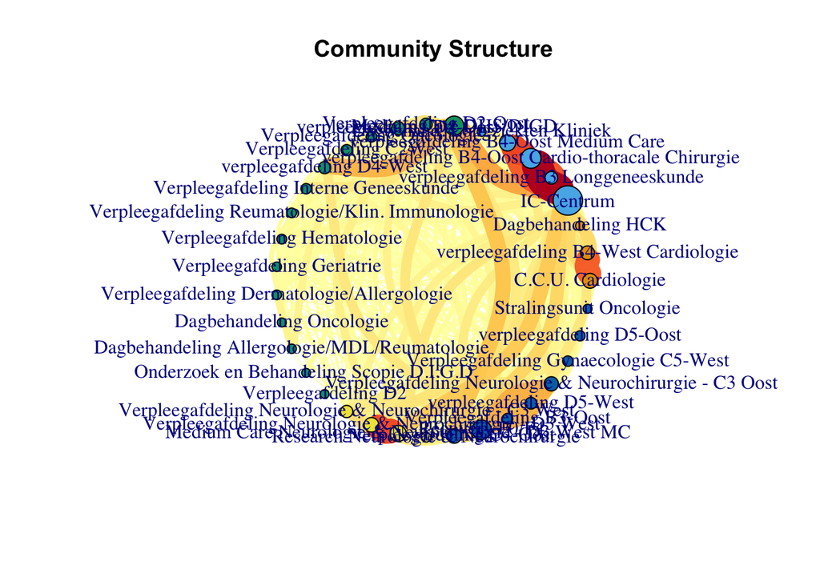

```r
# Sort nodes within each community based on node degree
sorted_nodes <- lapply( unique( membership ), function( community ) { # use membership for louvain
  community_nodes <- which( membership == community ) # use membership for louvain
  node_degrees_community <- node_degrees[ community_nodes ]
  community_nodes[ order( node_degrees_community, decreasing = TRUE )]
})

# Combine the sorted nodes into a single vector
sorted_nodes <- unlist( sorted_nodes )

# Manually adjust the positions in a circular layout, placing members of the same community next to each other
layout <- layout_in_circle( undirected_graph, order = sorted_nodes )
#layout <- layout_with_kk( undirected_graph, weights = edges2$weight**-0.3 )
#layout <- layout_with_fr( undirected_graph )

# Plot the graph with community colors, node size, and edge thickness
plot(
  undirected_graph,
  layout = layout,
  vertex.color = membership, # use membership for louvain
  vertex.size = scaled_weights**0.75,
  #edge.color = ifelse( paste( edges2$from, edges2$to ) %in% paste( top_edges$from, top_edges$to ), "red", "grey" ),
  #edge.width = ifelse( paste( edges2$from, edges2$to ) %in% paste( top_edges$from, top_edges$to ), 8, 1 ),
  edge.width = edge_thickness**0.5,
  edge.color = adjustcolor(edge_colors),#, alpha.f = 0.8),  # Set edge colors
  main = "Community Structure",
  edge.alpha = 0.1
)
```

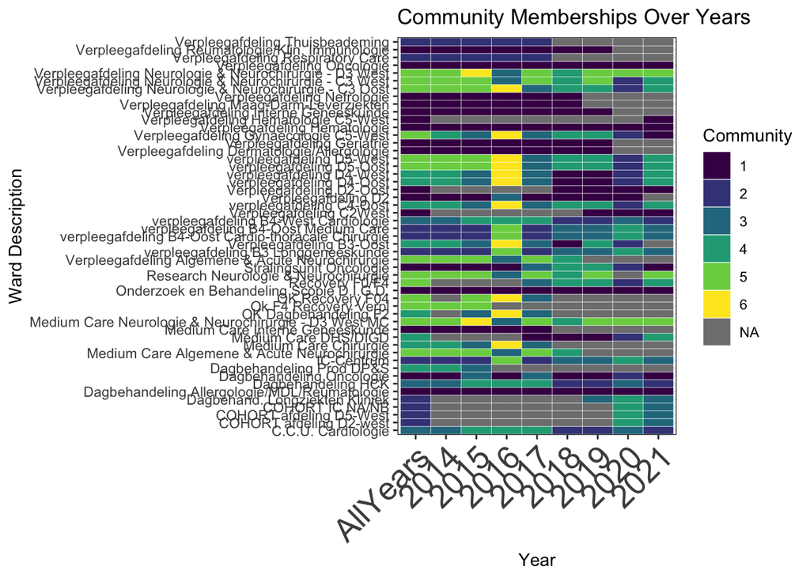

```r
# Split data based on hos_mut_Afd_code
subset_df_split <- Patient_movements5 %>%
  #filter(year(hos_start_dt) == 2019) %>%
  mutate(
    group_category = case_when(
      grepl("^I", hos_mut_Afd_code) ~ "Group1",
      grepl("^F", hos_mut_Afd_code) & hos_mut_Afd_code != "F320" ~ "Group1",
      hos_mut_Afd_code == "Z350" ~ "Group1",
      TRUE ~ "Rest"
    )
  )

# Extract the subset of columns for the graph
subset_df_WKZ <- subset_df_split %>%
  filter(group_category == "Group1")

subset_df_UMCU <- subset_df_split %>%
  filter(group_category == "Rest")

data.choice <- subset_df_UMCU

# Function to create a graph and extract communities
get_communities <- function( data, years, optimal_k ) {
  # Filter data for the base case year
  subset_df <- data %>% filter( year( hos_start_dt ) == years)

  # Extract the subset of columns for the graph
  subset_df <- subset_df[ , c( "studyId_outbreakdetec_Hos_ID", "hos_mut_Afd_code" )]

  subset_df <- subset_df %>% arrange( studyId_outbreakdetec_Hos_ID )

  # Create an edge list based on patient transfers between 'hos_mut_specialism'
  edges <- subset_df %>%
    group_by( studyId_outbreakdetec_Hos_ID ) %>%
    mutate( previous_hos_mut_Afd_code = lag( hos_mut_Afd_code )) %>%
    filter( !is.na(previous_hos_mut_Afd_code ) & hos_mut_Afd_code != previous_hos_mut_Afd_code ) %>%
    select( from = previous_hos_mut_Afd_code, to = hos_mut_Afd_code ) %>%
    ungroup()

  edges <- edges %>% arrange( studyId_outbreakdetec_Hos_ID )

  # Select the second and third column
  edges <- edges[ , c( 2, 3 )]

  # Merge similar edges and add weight
  edges2 <- edges %>%
    group_by( from, to ) %>%
    summarise( weight = n() ) %>%
    ungroup()

  # Create an undirected graph from the edge list
  undirected_graph <- graph.data.frame( edges2, directed = FALSE )

  # Use the kmeans clustering
  set.seed(25)

  # Use the Louvain method for community detection
  communities <- cluster_louvain( undirected_graph )
  return( membership( communities ))
}

# Create a list to store community memberships for each year
#community_list <- lapply( 2014:2021, function( years ) get_communities( data.choice, years ))
set.seed(25)
community_list <- lapply(2014:2021, function(years)
  get_communities(data.choice, years, optimal_k_values[years - 2013]))

# Function to create communities for the entire dataset
get_communities_all_years <- function(data) {
  subset_df <- data[, c("studyId_outbreakdetec_Hos_ID", "hos_mut_Afd_code")]
  subset_df <- subset_df %>% arrange(studyId_outbreakdetec_Hos_ID)

  edges <- subset_df %>%
    group_by(studyId_outbreakdetec_Hos_ID) %>%
    mutate(previous_hos_mut_Afd_code = lag(hos_mut_Afd_code)) %>%
    filter(!is.na(previous_hos_mut_Afd_code) & hos_mut_Afd_code != previous_hos_mut_Afd_code) %>%
    select(from = previous_hos_mut_Afd_code, to = hos_mut_Afd_code) %>%
    ungroup()

  edges <- edges %>% arrange(studyId_outbreakdetec_Hos_ID)

  edges <- edges[, c(2, 3)]

  edges2 <- edges %>%
    group_by(from, to) %>%
    summarise(weight = n()) %>%
    ungroup()

  undirected_graph <- graph.data.frame(edges2, directed = FALSE)

  # use the kmeans clustering
  set.seed(25)

  communities <- cluster_louvain(undirected_graph)
  return(membership(communities))
}

# Create community memberships for the entire dataset
all_years_communities <- get_communities_all_years(data.choice)

# Extract node names (wards)
nodes <- unique( c( data.choice$hos_mut_Afd_code ))

# Create a data frame to store the results
result_df <- data.frame( Ward = character(), stringsAsFactors = FALSE )

# Compare community memberships for each ward across years
for ( ward in nodes ) {
  ward_result <- data.frame( Ward = ward, stringsAsFactors = FALSE )
  for ( i in 1:length( community_list )) {
    ward_result[[ as.character( 2014 + i - 1 )]] <- community_list[[ i ]][ ward ]
  }
  result_df <- rbind( result_df, ward_result )
}

result_df <- result_df[ order( result_df$Ward ), ]
# Append the column for clusters made over all years to each corresponding row
result_df$AllYears <- all_years_communities[result_df$Ward]
# Reorder the columns, placing 'AllYears' as the first column
result_df <- result_df[c("Ward", "AllYears", colnames(result_df)[!colnames(result_df) %in% c("Ward", "AllYears")])]

# Melt the data frame for easier plotting
melted_result.UMCU <- reshape2::melt( result_df, id.vars = "Ward", variable.name = "Year", value.name = "Community" )

# Define a color palette with n distinct colors
community_colors <- viridis( 6, option = "D" )
# palette1 <- brewer.pal(8, "Set1")
# palette2 <- brewer.pal(8, "Set2")
# community_colors <- c(palette1, palette2)

# Create a mapping between hos_mut_Afd_code and hos_mut_afd_Omschrijving
code_to_description <- unique(data.choice[, c("hos_mut_Afd_code", "hos_mut_afd_Omschrijving")])

# Replace the 'Ward' column values in the melted result with the corresponding descriptions
melted_result.UMCU$Ward <- code_to_description$hos_mut_afd_Omschrijving[match(melted_result.UMCU$Ward, code_to_description$hos_mut_Afd_code)]

# Define a color palette with n distinct colors
community_colors <- viridis(6, option = "D")

# Plot a heatmap with the updated y-axis labels
ggplot(melted_result.UMCU, aes(x = Year, y = Ward, fill = factor(Community))) +
  geom_tile(color = "white") +
  scale_fill_manual(values = community_colors) +  # Use the defined color palette
  theme_bw() +
  labs(title = "Community Memberships Over Years", x = "Year", y = "Ward Description", fill = "Community") +
  theme(axis.text.x = element_text(angle = 45, hjust = 1, size = 20))
```

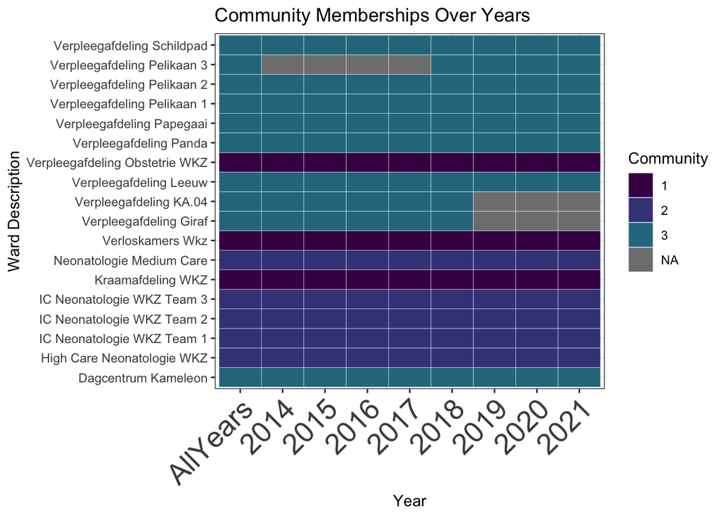

```r
# Split data based on hos_mut_Afd_code
subset_df_split <- Patient_movements5 %>%
  #filter(year(hos_start_dt) == 2019) %>%
  mutate(
    group_category = case_when(
      grepl("^I", hos_mut_Afd_code) ~ "Group1",
      grepl("^F", hos_mut_Afd_code) & hos_mut_Afd_code != "F320" ~ "Group1",
      hos_mut_Afd_code == "Z350" ~ "Group1",
      TRUE ~ "Rest"
    )
  )

# Extract the subset of columns for the graph
subset_df_WKZ <- subset_df_split %>%
  filter(group_category == "Group1")

subset_df_UMCU <- subset_df_split %>%
  filter(group_category == "Rest")

data.choice <- subset_df_WKZ

# Function to create a graph and extract communities
get_communities <- function( data, years, optimal_k ) {
  # Filter data for the base case year
  subset_df <- data %>% filter( year( hos_start_dt ) == years)

  # Extract the subset of columns for the graph
  subset_df <- subset_df[ , c( "studyId_outbreakdetec_Hos_ID", "hos_mut_Afd_code" )]

  subset_df <- subset_df %>% arrange( studyId_outbreakdetec_Hos_ID )

  # Create an edge list based on patient transfers between 'hos_mut_specialism'
  edges <- subset_df %>%
    group_by( studyId_outbreakdetec_Hos_ID ) %>%
    mutate( previous_hos_mut_Afd_code = lag( hos_mut_Afd_code )) %>%
    filter( !is.na(previous_hos_mut_Afd_code ) & hos_mut_Afd_code != previous_hos_mut_Afd_code ) %>%
    select( from = previous_hos_mut_Afd_code, to = hos_mut_Afd_code ) %>%
    ungroup()

  edges <- edges %>% arrange( studyId_outbreakdetec_Hos_ID )

  # Select the second and third column
  edges <- edges[ , c( 2, 3 )]

  # Merge similar edges and add weight
  edges2 <- edges %>%
    group_by( from, to ) %>%
    summarise( weight = n() ) %>%
    ungroup()

  # Create an undirected graph from the edge list
  undirected_graph <- graph.data.frame( edges2, directed = FALSE )

  # Use the kmeans clustering
  set.seed(25)

  # Use the Louvain method for community detection
  communities <- cluster_louvain( undirected_graph )
  return( membership( communities ))
}

# Create a list to store community memberships for each year
#community_list <- lapply( 2014:2021, function( years ) get_communities( data.choice, years ))
set.seed(25)
community_list <- lapply(2014:2021, function(years) get_communities(data.choice, years, optimal_k_values[years - 2013]))

# Function to create communities for the entire dataset
get_communities_all_years <- function(data) {
  subset_df <- data[, c("studyId_outbreakdetec_Hos_ID", "hos_mut_Afd_code")]
  subset_df <- subset_df %>% arrange(studyId_outbreakdetec_Hos_ID)

  edges <- subset_df %>%
    group_by(studyId_outbreakdetec_Hos_ID) %>%
    mutate(previous_hos_mut_Afd_code = lag(hos_mut_Afd_code)) %>%
    filter(!is.na(previous_hos_mut_Afd_code) & hos_mut_Afd_code != previous_hos_mut_Afd_code) %>%
    select(from = previous_hos_mut_Afd_code, to = hos_mut_Afd_code) %>%
    ungroup()

  edges <- edges %>% arrange(studyId_outbreakdetec_Hos_ID)

  edges <- edges[, c(2, 3)]

  edges2 <- edges %>%
    group_by(from, to) %>%
    summarise(weight = n()) %>%
    ungroup()

  undirected_graph <- graph.data.frame(edges2, directed = FALSE)

  # use the kmeans clustering
  set.seed(25)

  communities <- cluster_louvain(undirected_graph)
  return(membership(communities))
}

# Create community memberships for the entire dataset
all_years_communities <- get_communities_all_years(data.choice)

# Extract node names (wards)
nodes <- unique( c( data.choice$hos_mut_Afd_code ))

# Create a data frame to store the results
result_df <- data.frame( Ward = character(), stringsAsFactors = FALSE )

# Compare community memberships for each ward across years
for ( ward in nodes ) {
  ward_result <- data.frame( Ward = ward, stringsAsFactors = FALSE )
  for ( i in 1:length( community_list )) {
    ward_result[[ as.character( 2014 + i - 1 )]] <- community_list[[ i ]][ ward ]
  }
  result_df <- rbind( result_df, ward_result )
}

result_df <- result_df[ order( result_df$Ward ), ]
# Append the column for clusters made over all years to each corresponding row
result_df$AllYears <- all_years_communities[result_df$Ward]
# Reorder the columns, placing 'AllYears' as the first column
result_df <- result_df[c("Ward", "AllYears", colnames(result_df)[!colnames(result_df) %in% c("Ward", "AllYears")])]

# Melt the data frame for easier plotting
melted_result.WKZ <- reshape2::melt( result_df, id.vars = "Ward", variable.name = "Year", value.name = "Community" )

# Define a color palette with n distinct colors
community_colors <- viridis( 6, option = "D" )
# palette1 <- brewer.pal(8, "Set1")
# palette2 <- brewer.pal(8, "Set2")
# community_colors <- c(palette1, palette2)

# Create a mapping between hos_mut_Afd_code and hos_mut_afd_Omschrijving
code_to_description <- unique(data.choice[, c("hos_mut_Afd_code", "hos_mut_afd_Omschrijving")])

# Replace the 'Ward' column values in the melted result with the corresponding descriptions
melted_result.WKZ$Ward <- code_to_description$hos_mut_afd_Omschrijving[match(melted_result.WKZ$Ward, code_to_description$hos_mut_Afd_code)]

# Define a color palette with n distinct colors
community_colors <- viridis(6, option = "D")

# Plot a heatmap with the updated y-axis labels
ggplot(melted_result.WKZ, aes(x = Year, y = Ward, fill = factor(Community))) +
  geom_tile(color = "white") +
  scale_fill_manual(values = community_colors) +  # Use the defined color palette
  theme_bw() +
  labs(title = "Community Memberships Over Years", x = "Year", y = "Ward Description", fill = "Community") +
  theme(axis.text.x = element_text(angle = 45, hjust = 1, size = 20))
```

```r
melted_result.UMCU$Hospital <- "UMCU"
melted_result.WKZ$Hospital <- "WKZ"

Louvain.cluster.results <- rbind(melted_result.UMCU, melted_result.WKZ)

# Save the data
write.table(
  Louvain.cluster.results,
  file = here("Patient_movements", "Data", "Louvain.cluster.results.csv"),
  sep = ";",
  row.names = FALSE
)
```